# Statistics Project – Part 2

```r
trn_fit_data
```

| Date | Avg_Tok_Amt | Tot_Tok_Amt | Transactions | Distinct_Buyers | Distinct_Sellers | Open | High | Low | Close | Volume | MarketCap | Close_m1 | Close_m2 | Close_m3 |
| --- | --- | --- | --- | --- | --- | --- | --- | --- | --- | --- | --- | --- | --- | --- |
| 2017-09-28 | 3.334170e+14 | 1.000251e+15 | 3 | 1 | 2 | 0.002563 | 0.003474 | 0.001816 | 0.002906 | 69,532 | 29,255,845 | NA | NA | NA |
| 2017-10-01 | 2.051696e+12 | 1.436187e+13 | 7 | 1 | 7 | 0.002261 | 0.002269 | 0.001806 | 0.001848 | 72,807 | 18,600,627 | 0.002906 | NA | NA |
| 2017-10-02 | 2.478180e+12 | 3.989870e+14 | 161 | 1 | 134 | 0.001848 | 0.003177 | 0.001768 | 0.002803 | 887,622 | 112,120,400 | 0.001848 | 0.002906 | NA |
| 2017-10-03 | 3.128965e+12 | 1.533193e+14 | 49 | 1 | 46 | 0.002748 | 0.003186 | 0.002128 | 0.002447 | 822,107 | 97,860,400 | 0.002803 | 0.001848 | 0.002906 |
| 2017-10-04 | 3.033677e+12 | 2.457278e+14 | 81 | 1 | 65 | 0.002469 | 0.003521 | 0.002400 | 0.003250 | 1,072,200 | 130,009,600 | 0.002447 | 0.002803 | 0.001848 |
| 2017-10-05 | 2.462115e+12 | 1.304921e+14 | 53 | 1 | 33 | 0.003269 | 0.003488 | 0.002942 | 0.003320 | 704,167 | 132,808,800 | 0.003250 | 0.002447 | 0.002803 |
| 2017-10-06 | 4.072675e+12 | 1.547616e+14 | 38 | 1 | 30 | 0.003321 | 0.003354 | 0.002815 | 0.002996 | 478,330 | 119,821,600 | 0.003320 | 0.003250 | 0.002447 |
| 2017-10-07 | 1.104156e+12 | 5.410364e+13 | 49 | 3 | 46 | 0.002995 | 0.004173 | 0.002240 | 0.002459 | 352,974 | 160,132,110 | 0.002996 | 0.003320 | 0.003250 |
| 2017-10-08 | 6.938313e+11 | 2.150877e+13 | 31 | 2 | 29 | 0.002565 | 0.002854 | 0.002326 | 0.002530 | 239,490 | 164,739,648 | 0.002459 | 0.002996 | 0.003320 |
| 2017-10-09 | 1.245909e+12 | 6.478725e+13 | 52 | 3 | 51 | 0.002567 | 0.002719 | 0.001943 | 0.002181 | 350,960 | 142,021,024 | 0.002530 | 0.002459 | 0.002996 |

[output cut: 209 more lines]

```r
yoc_fit_data
```

| Date | Avg_Tok_Amt | Tot_Tok_Amt | Transactions | Distinct_Buyers | Distinct_Sellers | Open | High | Low | Close | Volume | MarketCap | Close_m1 | Close_m2 | Close_m3 |
| --- | --- | --- | --- | --- | --- | --- | --- | --- | --- | --- | --- | --- | --- | --- |
| 2016-08-01 | 9.317698e+18 | 4.658849e+19 | 5 | 3 | 3 | 0.198319 | 0.223192 | 0.173802 | 0.175498 | 16,031 | 3,544,165 | NA | NA | NA |
| 2016-08-02 | 2.090916e+18 | 1.338186e+20 | 64 | 8 | 3 | 0.174383 | 0.227272 | 0.151030 | 0.154217 | 21,636 | 3,114,397 | 0.175498 | NA | NA |
| 2016-08-04 | 2.754744e+19 | 2.754744e+20 | 10 | 2 | 1 | 0.171559 | 0.178511 | 0.164972 | 0.171830 | 25,837 | 3,470,090 | 0.154217 | 0.175498 | NA |
| 2016-08-07 | 1.318709e+19 | 2.241805e+20 | 17 | 6 | 2 | 0.181118 | 0.181962 | 0.171257 | 0.179511 | 7,942 | 3,625,207 | 0.171830 | 0.154217 | 0.175498 |
| 2016-08-08 | 3.767750e+18 | 7.535500e+18 | 2 | 1 | 1 | 0.179528 | 0.196012 | 0.166275 | 0.174715 | 11,921 | 3,528,352 | 0.179511 | 0.171830 | 0.154217 |
| 2016-08-09 | 1.440167e+18 | 4.320500e+18 | 3 | 2 | 2 | 0.174739 | 0.175596 | 0.151049 | 0.169797 | 14,986 | 3,429,033 | 0.174715 | 0.179511 | 0.171830 |
| 2016-08-10 | 1.246500e+18 | 5.609250e+19 | 45 | 15 | 4 | 0.167181 | 0.192224 | 0.160545 | 0.184903 | 17,369 | 3,734,098 | 0.169797 | 0.174715 | 0.179511 |
| 2016-08-11 | 2.013349e+19 | 1.409344e+20 | 7 | 2 | 2 | 0.184987 | 0.185254 | 0.162635 | 0.170772 | 29,844 | - | 0.184903 | 0.169797 | 0.174715 |
| 2016-08-12 | 2.208708e+20 | 4.019849e+22 | 182 | 23 | 8 | 0.169817 | 0.170068 | 0.147820 | 0.155941 | 20,358 | - | 0.170772 | 0.184903 | 0.169797 |
| 2016-08-13 | 1.892581e+18 | 1.854729e+20 | 98 | 15 | 7 | 0.156428 | 0.166311 | 0.144135 | 0.154937 | 30,778 | - | 0.155941 | 0.170772 | 0.184903 |

[output cut: 409 more lines]

Let’s also take a look at how many days are tracked for the three tokens in our data sets. We have the most data for YOC.

```r
cat("OMG Rows: ", nrow(omg_fit_data), "\n")
```

```
OMG Rows:  297
```

```r
cat("TRX Rows: ", nrow(trn_fit_data), "\n")
```

```
TRX Rows:  219
```

```r
cat("YOC Rows: ", nrow(yoc_fit_data), "\n")
```

```
YOC Rows:  419
```

We chose to regress to the Close value of the token, so we will compare the correlation of each of the regressors (Xs) to the Close (Y).

We can make the observation from this data that the previous day’s prices are far more correlated to the Close price on the day when compared to the token amounts, distinct buyers, and other features we engineered. This is expected.

```r
cat("OMG\n")
```

```
OMG
```

```r
cat("Transactions:         ", cor(omg_fit_data$Close, omg_fit_data$Transactions), "\n")
```

```
Transactions:          0.3102709
```

```r
cat("Total Token Amount:  ", cor(omg_fit_data$Close, omg_fit_data$Tot_Tok_Amt), "\n")
```

```
Total Token Amount:   -0.2595531
```

```r
cat("Average Token Amount:", cor(omg_fit_data$Close, omg_fit_data$Avg_Tok_Amt), "\n")
```

```
Average Token Amount: -0.42185
```

```r
cat("Distinct Buyers:      ", cor(omg_fit_data$Close, omg_fit_data$Distinct_Buyers), "\n")
```

```
Distinct Buyers:       0.581282
```

```r
cat("Distinct Sellers:     ", cor(omg_fit_data$Close, omg_fit_data$Distinct_Sellers), "\n")
```

```
Distinct Sellers:      0.2064471
```

```r
cat("Close Minus 1:        ", cor(omg_fit_data$Close, omg_fit_data$Close_m1, use = "complete.obs"), "\n")
```

```
Close Minus 1:         0.9786079
```

```r
cat("Close Minus 2:        ", cor(omg_fit_data$Close, omg_fit_data$Close_m2, use = "complete.obs"), "\n")
```

```
Close Minus 2:         0.9591295
```

```r
cat("Close Minus 3:        ", cor(omg_fit_data$Close, omg_fit_data$Close_m3, use = "complete.obs"), "\n")
```

```
Close Minus 3:         0.9387131
```

```r
cat("\n\nTRX\n")
```

```
TRX
```

```r
cat("Transactions:         ", cor(trn_fit_data$Close, trn_fit_data$Transactions), "\n")
```

```
Transactions:          0.2681442
```

```r
cat("Total Token Amount:   ", cor(trn_fit_data$Close, trn_fit_data$Tot_Tok_Amt), "\n")
```

```
Total Token Amount:    0.2224408
```

```r
cat("Average Token Amount:", cor(trn_fit_data$Close, trn_fit_data$Avg_Tok_Amt), "\n")
```

```
Average Token Amount: -0.08771963
```

```r
cat("Distinct Buyers:      ", cor(trn_fit_data$Close, trn_fit_data$Distinct_Buyers), "\n")
```

```
Distinct Buyers:       0.501484
```

```r
cat("Distinct Sellers:     ", cor(trn_fit_data$Close, trn_fit_data$Distinct_Sellers), "\n")
```

```
Distinct Sellers:      0.1954086
```

```r
cat("Close Minus 1:        ", cor(trn_fit_data$Close, trn_fit_data$Close_m1, use = "complete.obs"), "\n")
```

```
Close Minus 1:         0.9589376
```

```r
cat("Close Minus 2:        ", cor(trn_fit_data$Close, trn_fit_data$Close_m2, use = "complete.obs"), "\n")
```

```
Close Minus 2:         0.9108625
```

```r
cat("Close Minus 3:        ", cor(trn_fit_data$Close, trn_fit_data$Close_m3, use = "complete.obs"), "\n")
```

```
Close Minus 3:         0.8584132
```

```r
cat("\n\nYOC\n")
```

```
YOC
```

```r
cat("Transactions:        ", cor(yoc_fit_data$Close, yoc_fit_data$Transactions), "\n")
```

```
Transactions:         -0.03276647
```

```r
cat("Total Token Amount:  ", cor(yoc_fit_data$Close, yoc_fit_data$Tot_Tok_Amt), "\n")
```

```
Total Token Amount:   -0.291548
```

```r
cat("Average Token Amount:", cor(yoc_fit_data$Close, yoc_fit_data$Avg_Tok_Amt), "\n")
```

```
Average Token Amount: -0.2923831
```

```r
cat("Distinct Buyers:      ", cor(yoc_fit_data$Close, yoc_fit_data$Distinct_Buyers), "\n")
```

```
Distinct Buyers:       0.3710236
```

```r
cat("Distinct Sellers:     ", cor(yoc_fit_data$Close, yoc_fit_data$Distinct_Sellers), "\n")
```

```
Distinct Sellers:      0.05984299
```

```r
cat("Close Minus 1:        ", cor(yoc_fit_data$Close, yoc_fit_data$Close_m1, use = "complete.obs"), "\n")
```

```
Close Minus 1:         0.9806028
```

```r
cat("Close Minus 2:        ", cor(yoc_fit_data$Close, yoc_fit_data$Close_m2, use = "complete.obs"), "\n")
```

```
Close Minus 2:         0.9755522
```

```r
cat("Close Minus 3:        ", cor(yoc_fit_data$Close, yoc_fit_data$Close_m3, use = "complete.obs"), "\n")
```

```
Close Minus 3:         0.9712862
```

## Create the Multiple Linear Regression Model

Time to actually perform the fit via multiple linear regression. We will split each coin into two different models. The first considering the previous 3 days of Close prices. The second only focusing on the features we engineered. As the previous three days were so highly correlated with the price, they make the R^2 value significantly higher and we lose some understanding of which one of the engineered features actually contributes the most.

Note: The models ending in “_hist" take the price history for the three previous days into account. Those with “_no_hist" endings do not.

```r
omg_fit_hist <- lm(
  Close ~ Avg_Tok_Amt +
    Tot_Tok_Amt +
    Transactions +
    Distinct_Buyers +
    Distinct_Sellers +
    Close_m1 +
    Close_m2 +
    Close_m3,
  data=omg_fit_data)
omg_fit_no_hist <- lm(
  Close ~ Avg_Tok_Amt +
    Tot_Tok_Amt +
    Transactions +
    Distinct_Buyers +
    Distinct_Sellers,
  data=omg_fit_data)
trn_fit_hist <- lm(
  Close ~ Avg_Tok_Amt +
    Tot_Tok_Amt +
    Transactions +
    Distinct_Buyers +
    Distinct_Sellers +
    Close_m1 +
    Close_m2 +
    Close_m3,
  data=trn_fit_data)
trn_fit_no_hist <- lm(
  Close ~ Avg_Tok_Amt +
    Tot_Tok_Amt +
    Transactions +
    Distinct_Buyers +
    Distinct_Sellers,
  data=trn_fit_data)
yoc_fit_hist <- lm(
  Close ~ Avg_Tok_Amt +
    Tot_Tok_Amt +
    Transactions +
    Distinct_Buyers +
    Distinct_Sellers +
    Close_m1 +
    Close_m2 +
    Close_m3,
  data=yoc_fit_data)
yoc_fit_no_hist <- lm(
  Close ~ Avg_Tok_Amt +
    Tot_Tok_Amt +
    Transactions +
    Distinct_Buyers +
    Distinct_Sellers,
  data=yoc_fit_data)
```

### OMG Summary Data and Plots for Model with Close History

```r
cat("OMG with Close History")
```

```
OMG with Close History
```

```r
print(summary(omg_fit_hist))
```

```
Call:
lm(formula = Close ~ Avg_Tok_Amt + Tot_Tok_Amt + Transactions +
    Distinct_Buyers + Distinct_Sellers + Close_m1 + Close_m2 +
    Close_m3, data = omg_fit_data)

Residuals:
    Min      1Q  Median      3Q     Max
-4.8660 -0.4814 -0.0338  0.5035  4.9335

Coefficients:
                   Estimate Std. Error t value Pr(>|t|)
(Intercept)      -8.354e-02  2.696e-01  -0.310   0.7569
Avg_Tok_Amt      -5.982e-23  6.023e-23  -0.993   0.3215
Tot_Tok_Amt       1.922e-25  8.797e-26   2.185   0.0297 *
Transactions      1.286e-04  8.750e-05   1.470   0.1428
Distinct_Buyers   1.209e-02  7.394e-03   1.635   0.1031
Distinct_Sellers  7.884e-05  1.412e-04   0.558   0.5770
Close_m1          9.190e-01  5.787e-02  15.881   <2e-16 ***
Close_m2          3.226e-02  7.885e-02   0.409   0.6827
Close_m3         -1.387e-05  5.699e-02   0.000   0.9998
---
Signif. codes:  0 ‘***’ 0.001 ‘**’ 0.01 ‘*’ 0.05 ‘.’ 0.1 ‘ ’ 1

Residual standard error: 1.057 on 285 degrees of freedom
  (3 observations deleted due to missingness)
Multiple R-squared:  0.9599,    Adjusted R-squared:  0.9588
F-statistic: 853.6 on 8 and 285 DF,  p-value: < 2.2e-16
```

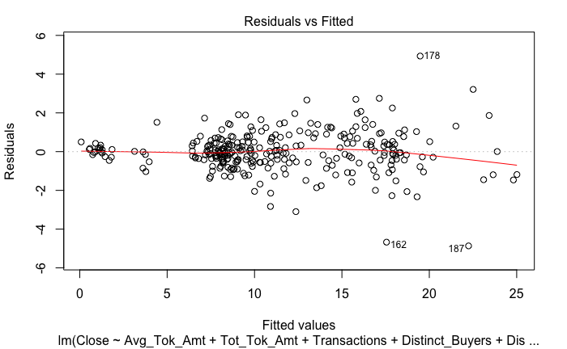

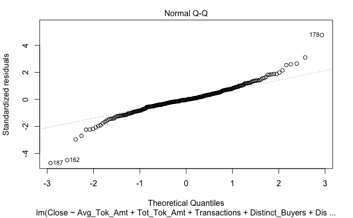

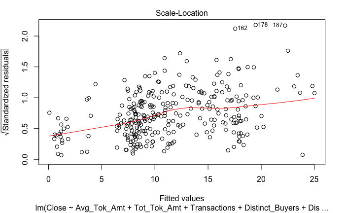

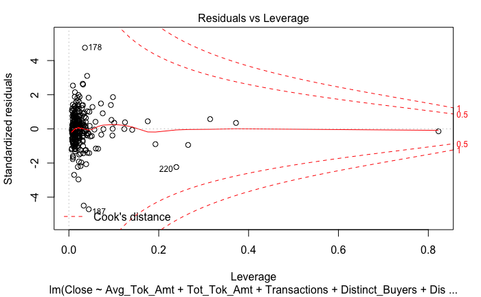

```r
plot(omg_fit_hist)
```

### OMG Summary Data and Plots for Model without Close History

```r
cat("OMG without Close History")
```

```
OMG without Close History
```

```r
print(summary(omg_fit_no_hist))
```

```
Call:
lm(formula = Close ~ Avg_Tok_Amt + Tot_Tok_Amt + Transactions +
    Distinct_Buyers + Distinct_Sellers, data = omg_fit_data)

Residuals:
    Min      1Q  Median      3Q     Max
-8.1907 -3.2593 -0.2358  2.5062 11.5329

Coefficients:
                   Estimate Std. Error t value Pr(>|t|)
(Intercept)       3.671e+00  9.006e-01   4.076 5.92e-05 ***
Avg_Tok_Amt      -2.563e-22  1.369e-22  -1.872   0.0622 .
Tot_Tok_Amt      -1.372e-25  2.975e-25  -0.461   0.6451
Transactions      1.528e-03  3.248e-04   4.706 3.91e-06 ***
Distinct_Buyers   2.294e-01  2.479e-02   9.254  < 2e-16 ***
Distinct_Sellers -1.334e-03  5.347e-04  -2.496   0.0131 *
---
Signif. codes:  0 ‘***’ 0.001 ‘**’ 0.01 ‘*’ 0.05 ‘.’ 0.1 ‘ ’ 1

Residual standard error: 4.093 on 291 degrees of freedom
Multiple R-squared:  0.4125,    Adjusted R-squared:  0.4024
F-statistic: 40.86 on 5 and 291 DF,  p-value: < 2.2e-16
```

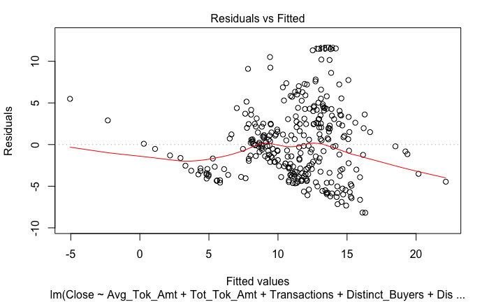

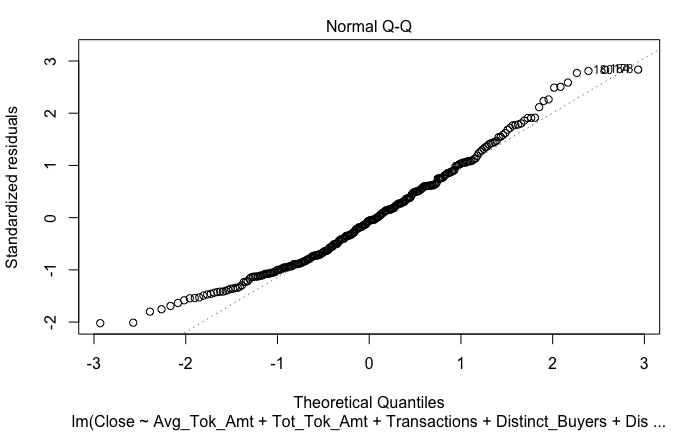

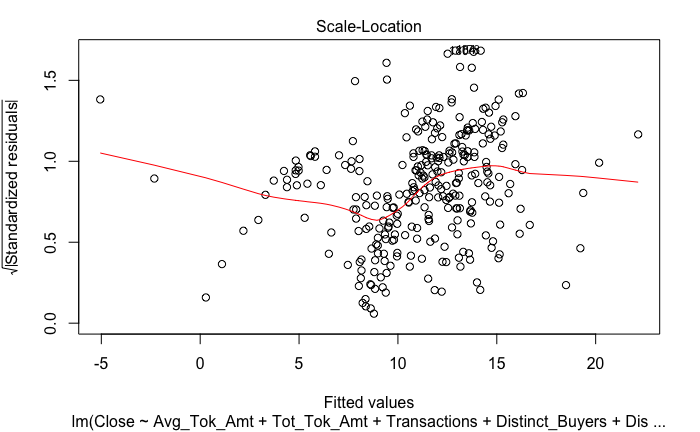

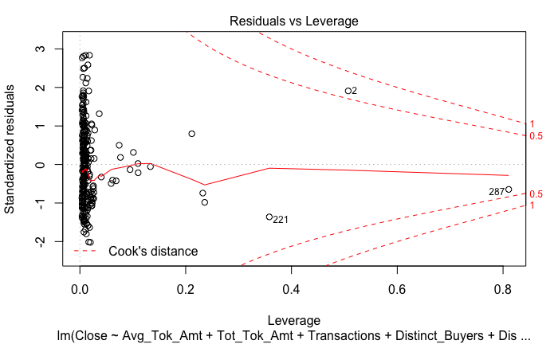

```r
plot(omg_fit_no_hist)
```

### TRX Summary Data and Plots for Model with Close History

```r
cat("TRX with Close History")
```

```
TRX with Close History
```

```r
print(summary(trn_fit_hist))
```

```
Call:
lm(formula = Close ~ Avg_Tok_Amt + Tot_Tok_Amt + Transactions +
    Distinct_Buyers + Distinct_Sellers + Close_m1 + Close_m2 +
    Close_m3, data = trn_fit_data)

Residuals:
      Min        1Q    Median        3Q       Max
-0.039689 -0.001343 -0.000461  0.001365  0.107725

Coefficients:
                   Estimate Std. Error t value Pr(>|t|)
(Intercept)       8.724e-04  1.718e-03   0.508 0.612205
Avg_Tok_Amt      -1.095e-16  5.855e-16  -0.187 0.851852
Tot_Tok_Amt       1.677e-19  9.988e-19   0.168 0.866848
Transactions      1.047e-05  3.001e-06   3.488 0.000594 ***
Distinct_Buyers  -1.549e-05  5.387e-05  -0.287 0.774047
Distinct_Sellers -1.064e-05  3.056e-06  -3.483 0.000606 ***
Close_m1          1.005e+00  6.698e-02  15.011  < 2e-16 ***
Close_m2         -2.431e-02  9.738e-02  -0.250 0.803066
Close_m3         -7.040e-02  6.818e-02  -1.033 0.303028
---
Signif. codes:  0 ‘***’ 0.001 ‘**’ 0.01 ‘*’ 0.05 ‘.’ 0.1 ‘ ’ 1

Residual standard error: 0.01025 on 207 degrees of freedom
  (3 observations deleted due to missingness)
Multiple R-squared:  0.9273,    Adjusted R-squared:  0.9245
F-statistic: 330.2 on 8 and 207 DF,  p-value: < 2.2e-16
```

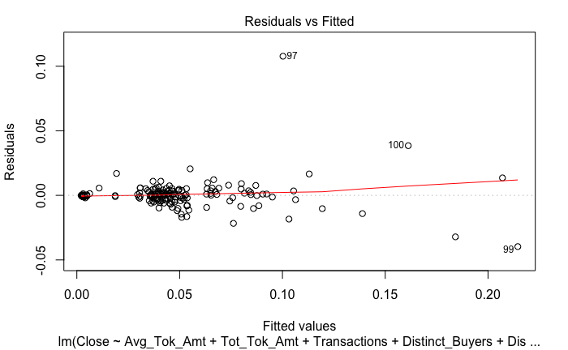

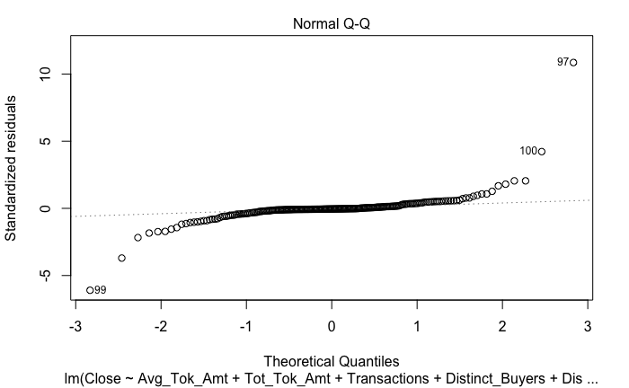

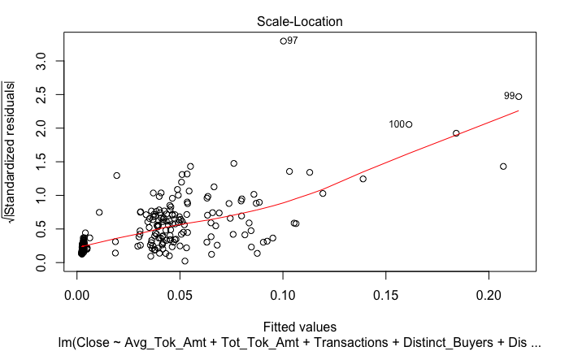

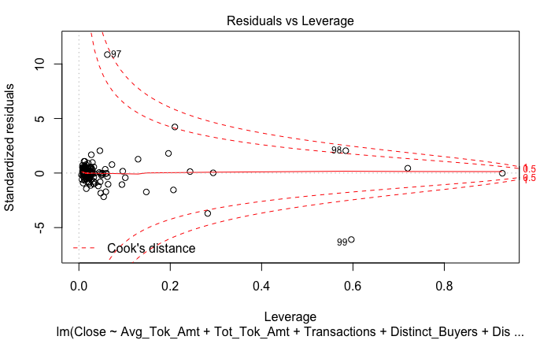

```r
plot(trn_fit_hist)
```

### TRX Summary Data and Plots for Models without Close History

```r
cat("TRX without Close History")
```

```
TRX without Close History
```

```r
print(summary(trn_fit_no_hist))
```

```
Call:
lm(formula = Close ~ Avg_Tok_Amt + Tot_Tok_Amt + Transactions +
    Distinct_Buyers + Distinct_Sellers, data = trn_fit_data)

Residuals:
      Min        1Q    Median        3Q       Max
-0.066925 -0.014493 -0.009785  0.005898  0.176164

Coefficients:
                   Estimate Std. Error t value Pr(>|t|)
(Intercept)       1.104e-02  3.878e-03   2.845 0.004867 **
Avg_Tok_Amt      -4.952e-17  9.502e-17  -0.521 0.602793
Tot_Tok_Amt       2.102e-18  2.693e-18   0.780 0.436004
Transactions      3.133e-05  8.929e-06   3.508 0.000550 ***
Distinct_Buyers   6.142e-04  1.518e-04   4.046 7.28e-05 ***
Distinct_Sellers -3.211e-05  9.120e-06  -3.521 0.000526 ***
---
Signif. codes:  0 ‘***’ 0.001 ‘**’ 0.01 ‘*’ 0.05 ‘.’ 0.1 ‘ ’ 1

Residual standard error: 0.03123 on 213 degrees of freedom
Multiple R-squared:  0.3142,    Adjusted R-squared:  0.2981
F-statistic: 19.52 on 5 and 213 DF,  p-value: 5.483e-16
```

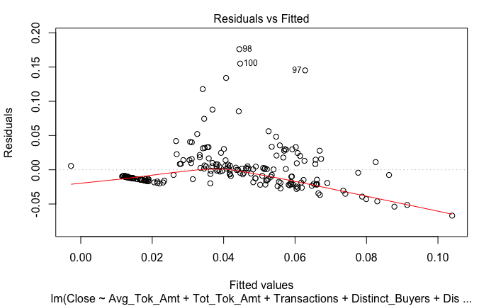

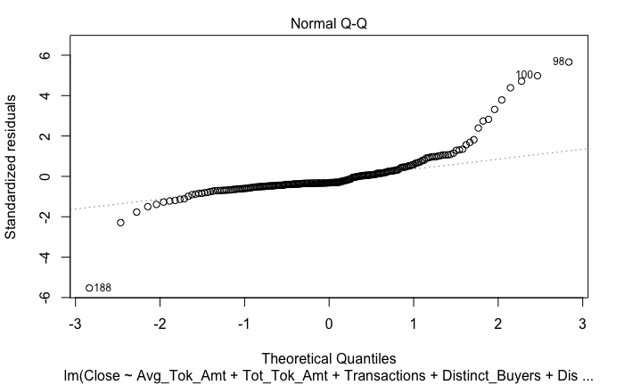

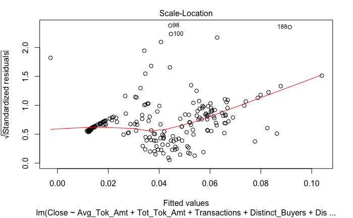

```
NaNs producedNaNs produced
```

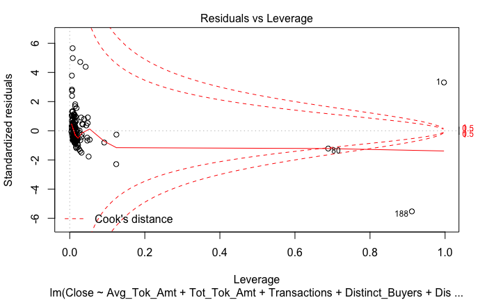

```r
plot(trn_fit_no_hist)
```

### YOC Summary Data and Plots for Model with Close History

```r
cat("YOC with Close History")
```

```
YOC with Close History
```

```r
print(summary(yoc_fit_hist))
```

```
Call:
lm(formula = Close ~ Avg_Tok_Amt + Tot_Tok_Amt + Transactions +
    Distinct_Buyers + Distinct_Sellers + Close_m1 + Close_m2 +
    Close_m3, data = yoc_fit_data)

Residuals:
      Min        1Q    Median        3Q       Max
-0.051715 -0.001443 -0.000642  0.001264  0.044352

Coefficients:
                   Estimate Std. Error t value Pr(>|t|)
(Intercept)       1.001e-03  7.286e-04   1.374 0.170177
Avg_Tok_Amt      -2.458e-25  5.014e-25  -0.490 0.624182
Tot_Tok_Amt       1.392e-28  4.807e-27   0.029 0.976914
Transactions     -1.061e-06  1.137e-06  -0.933 0.351432
Distinct_Buyers   2.912e-07  4.172e-05   0.007 0.994434
Distinct_Sellers  2.455e-06  5.291e-06   0.464 0.642888
Close_m1          5.633e-01  5.037e-02  11.184  < 2e-16 ***
Close_m2          2.302e-01  5.691e-02   4.045 6.27e-05 ***
Close_m3          1.739e-01  5.014e-02   3.468 0.000579 ***
---
Signif. codes:  0 ‘***’ 0.001 ‘**’ 0.01 ‘*’ 0.05 ‘.’ 0.1 ‘ ’ 1

Residual standard error: 0.007571 on 407 degrees of freedom
  (3 observations deleted due to missingness)
Multiple R-squared:  0.9664,    Adjusted R-squared:  0.9658
F-statistic:  1464 on 8 and 407 DF,  p-value: < 2.2e-16
```

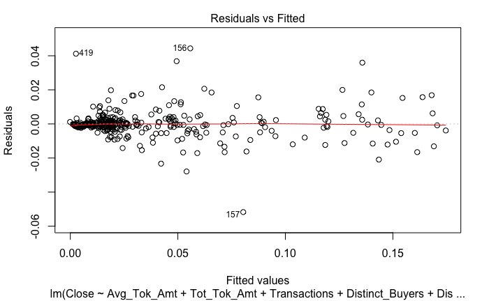

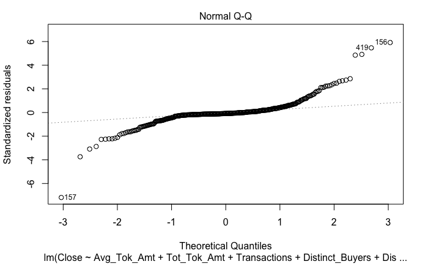

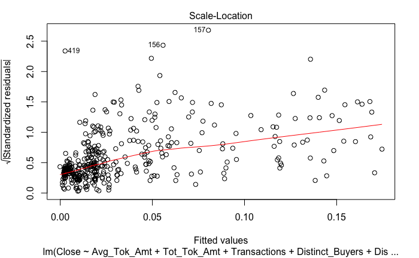

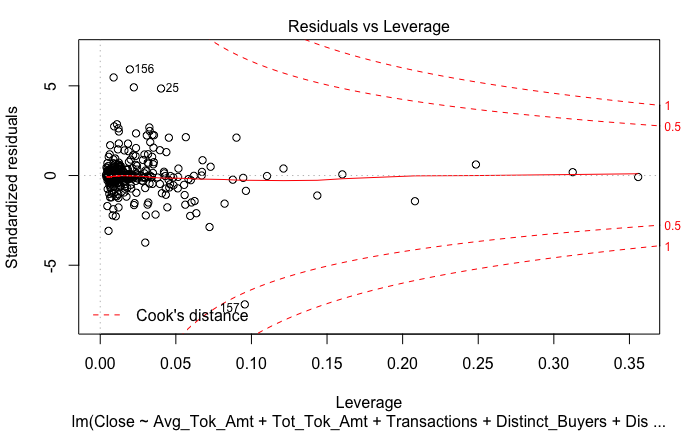

```r
plot(yoc_fit_hist)
```

### YOC Summary Data and Plots for Models without Close History

```r
cat("YOC without Close History")
```

```
YOC without Close History
```

```r
print(summary(yoc_fit_no_hist))
```

```
Call:
lm(formula = Close ~ Avg_Tok_Amt + Tot_Tok_Amt + Transactions +
    Distinct_Buyers + Distinct_Sellers, data = yoc_fit_data)

Residuals:
      Min        1Q    Median        3Q       Max
-0.061798 -0.025576 -0.005301  0.007639  0.139578

Coefficients:
                   Estimate Std. Error t value Pr(>|t|)
(Intercept)       3.360e-02  3.136e-03  10.713  < 2e-16 ***
Avg_Tok_Amt      -5.468e-24  2.422e-24  -2.258   0.0245 *
Tot_Tok_Amt      -4.442e-26  2.325e-26  -1.910   0.0568 .
Transactions     -3.208e-05  5.287e-06  -6.068 2.93e-09 ***
Distinct_Buyers   1.579e-03  1.830e-04   8.625  < 2e-16 ***
Distinct_Sellers  4.338e-05  2.529e-05   1.715   0.0870 .
---
Signif. codes:  0 ‘***’ 0.001 ‘**’ 0.01 ‘*’ 0.05 ‘.’ 0.1 ‘ ’ 1

Residual standard error: 0.0368 on 413 degrees of freedom
Multiple R-squared:  0.2522,    Adjusted R-squared:  0.2432
F-statistic: 27.86 on 5 and 413 DF,  p-value: < 2.2e-16
```

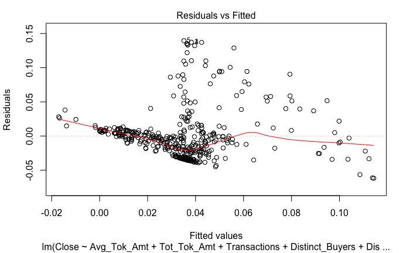

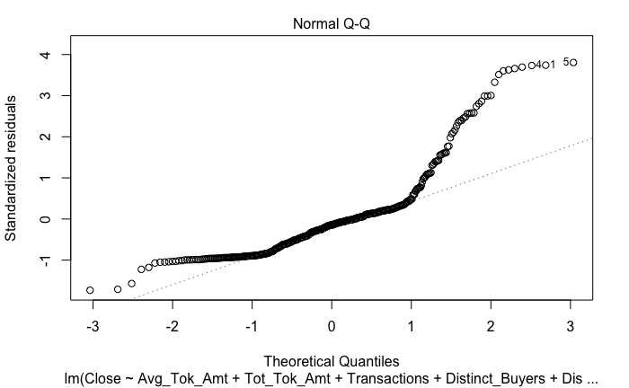

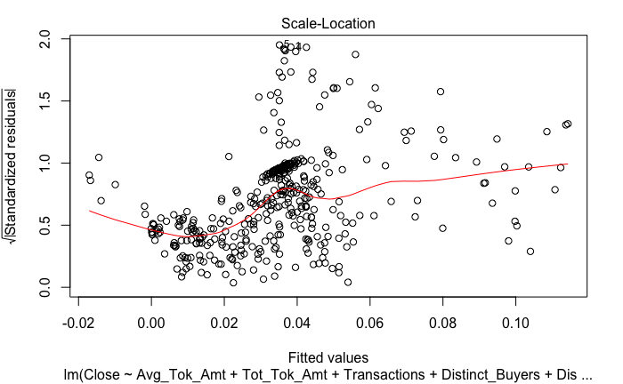

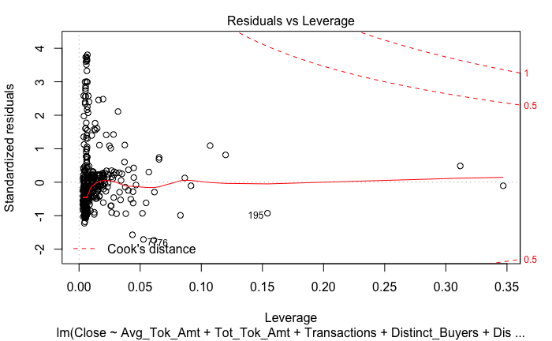

```r
plot(yoc_fit_no_hist)
```